# An Analysis of Physical Video Game Sales

36-315 Final Project (Fall 2025)

Albert Zhang (albertz2), Danny Weng (dannywen), Edward Brownhill (ebrownhi)

## Motivation

Over the past few decades, video games have become a more popular form of entertainment all around the world. Especially since the COVID-19 pandemic in which other activities became less feasible due to restrictions, video games have provided a way for people to entertain themselves, and have continued to grow in popularity even after restrictions end.

For regular people, understanding what types of games are popular can lead to more informed decision making, such as deciding what console to buy, if one has limited amounts of money. It can also be used to see what games have been most dominant worldwide, and if there is a difference in preferences for different regions or platforms.

For businesses, understanding common factors for the most successful and most popular games can help advise their own strategy for marketing or optimizing their own product. For game companies in particular, this data would be valuable as a benchmark for competitors, or insight into potentially good or bad collaborations.

## Data Description

The dataset contains a list of video games with sales over 100,000 copies, only including physical games, meaning there are no games sold digitally, free to play games, mobile games, indie games, etc. In this dataset, each row is a different game, and the columns consist of information like rank (based on sales), platform (PC, PS4, etc.), year of release, genre (shooter, sports, racing, etc.), publisher, sales in North America, Europe, Japan, the rest of the world, and worldwide (in millions of copies). The data can be found here: https://www.kaggle.com/datasets/gregorut/videogamesales?select=vgsales.csv but this source cites the data as being scraped from https://www.vgchartz.com.

## Research Questions

Based on this data and motivation, we came up with the following three main research questions we were interested in:

### 1. How has the video game industry changed over time?

Have certain regions become more or less dominant as the industry has evolved?

### 2. What are some notable differences between video game genres?

Are certain genres more or less popular in certain regions? Are these differences statistically significant?

### 3. What factors are associated with higher global sales?

What attributes of a game are useful in predicting the global sales of a game?

## Analysis

##### (Research Question 1)

One of our main questions of interests is about how the industry has changed over time. One way we can do this is by looking at how the number of global sales overall has changed, which can be seen through the 5-year moving average shown below:

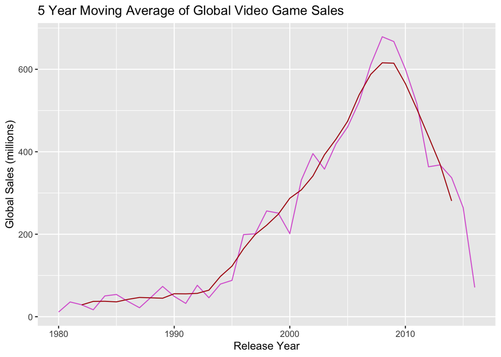

One thing to note for this graph (and all other graphs that utilize the Year variable) is that the x-axis is specifically game **release year**, not the year the sale occurred. This indicates that games released around 2008 (notably, Wii Sports, Mario Kart Wii, and Wii Sports Resort) were particularly strong compared to other years. The general trend of later years having higher global sales than earlier years (pre-2000s) demonstrates the growth of the industry.

Another point of interest might be to see how different regions capture shares of the global sales market over time, which can be seen in the graph below:

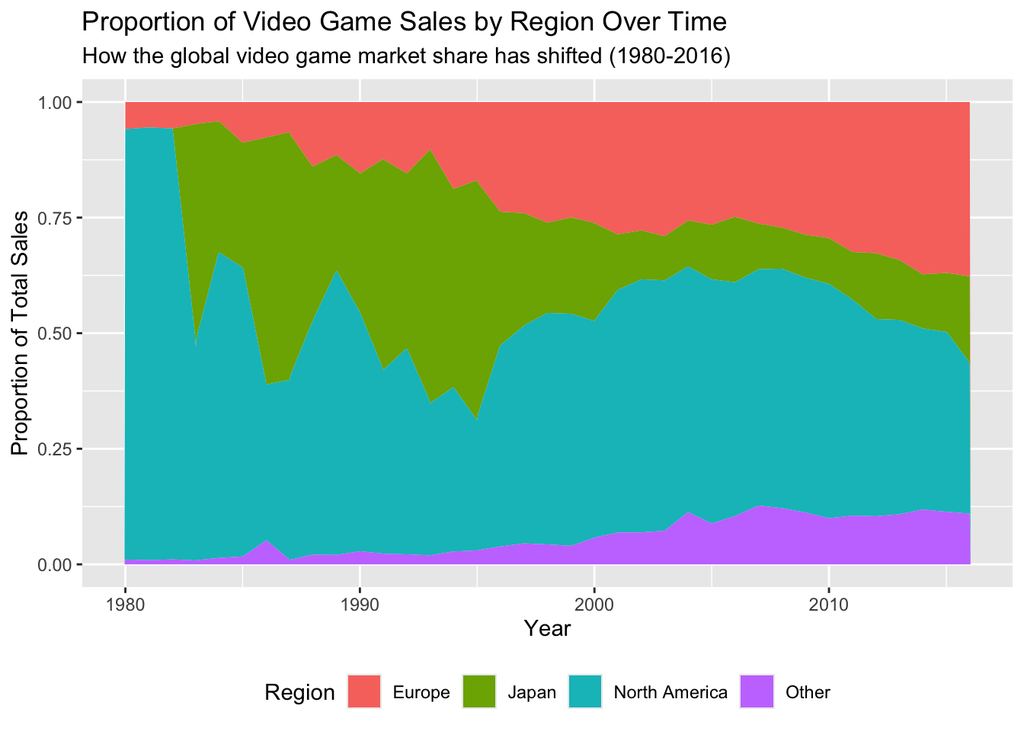

Based on this graph, we can see that the market was very dominated by North American sales in the early stages of the industry (around 1980s), and the intermediate stages saw a growth of Japan’s share of the industry (mid 1980s to mid 1990s). After 2000, Japan loses a bit of this share to Europe, North America and a little bit to “Other” regions.

We can also see the change in region sales (by count) over time with the following animation:

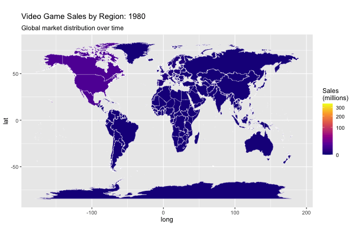

It is a bit hard to see Japan in the animation above, so we can also visualize the same data as follows:

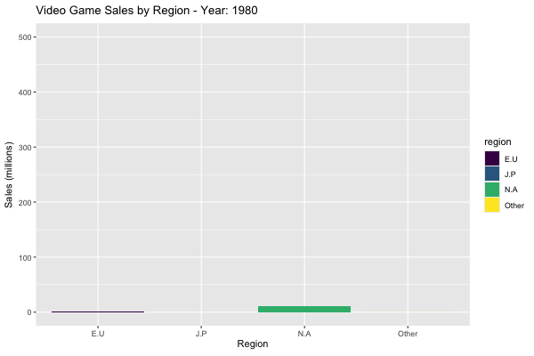

##### (Research Question 2)

Looking deeper into each region, we might be interested in finding out how popular different genres are overall, depending on the region. In particular, we can look at how much of a region’s sale each genre is to get a sense of how popular it is relative to other genres.

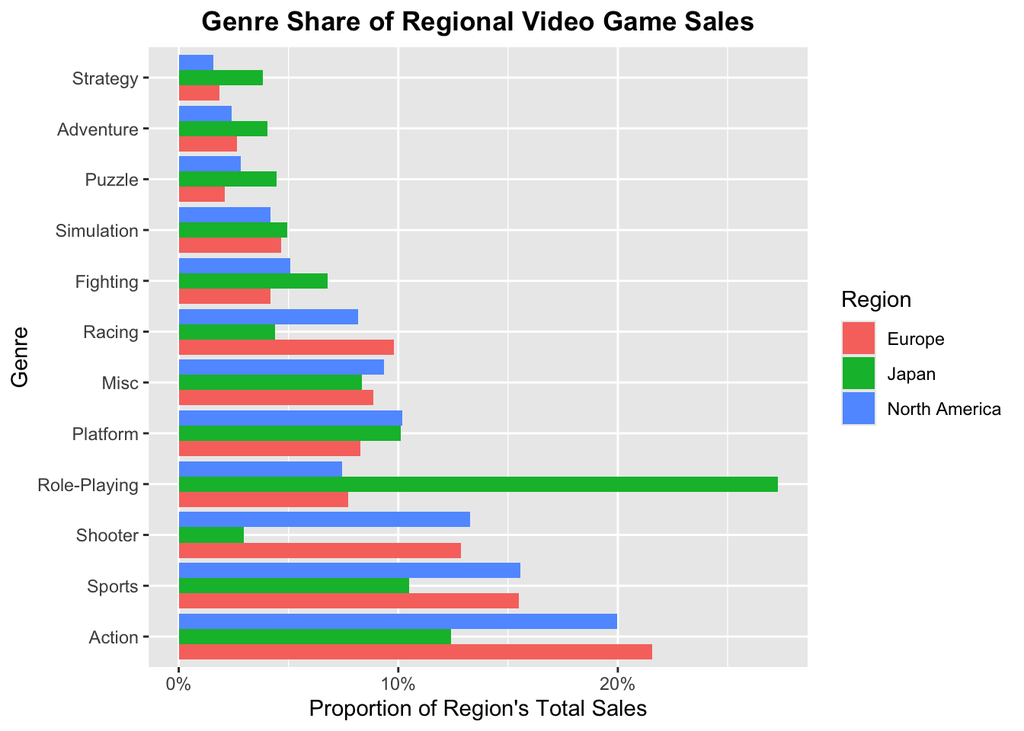

The plot compares how each region’s total sales are divided across genres. Japan stands out as being much more role-playing heavy than the other regions: RPGs make up a far larger share of Japanese sales than they do in North America or Europe. In contrast, North America and Europe devote more of their sales to action, shooter, and sports games, with Europe especially strong in action and North America stronger in sports and shooters. For most smaller genres (platform, puzzle, adventure, etc.) the shares are more similar, but overall the graph shows clearly different genre mixes across the three regions.

However, just to ensure that there is a difference in genre prevalences for the three regions represented in the data (North America, Europe, and Japan), we can run a chi-squared test of homogeneity for each combination of region and genre.

```
##
##  Pearson's Chi-squared test
##
## data:  sales_tab
## X-squared = 655.04, df = 22, p-value < 2.2e-16
```

We used a chi-square test to check whether the mix of genres is the same in North America, Europe, and Japan. The test result was statistically significant, with a p-value smaller than 2.2e-16, so we reject the null hypothesis that all three regions have the same genre proportions. This means the way total sales are split across genres really does differ by region. Looking at our genre proportion plot, Japan’s market devotes a much larger share of its sales to role-playing games, while North America and Europe allocate more of their sales to action, shooter, and sports titles.

Diving more into genre analysis, we can see how different genres sell globally, and how these sales break down across different platforms of games.

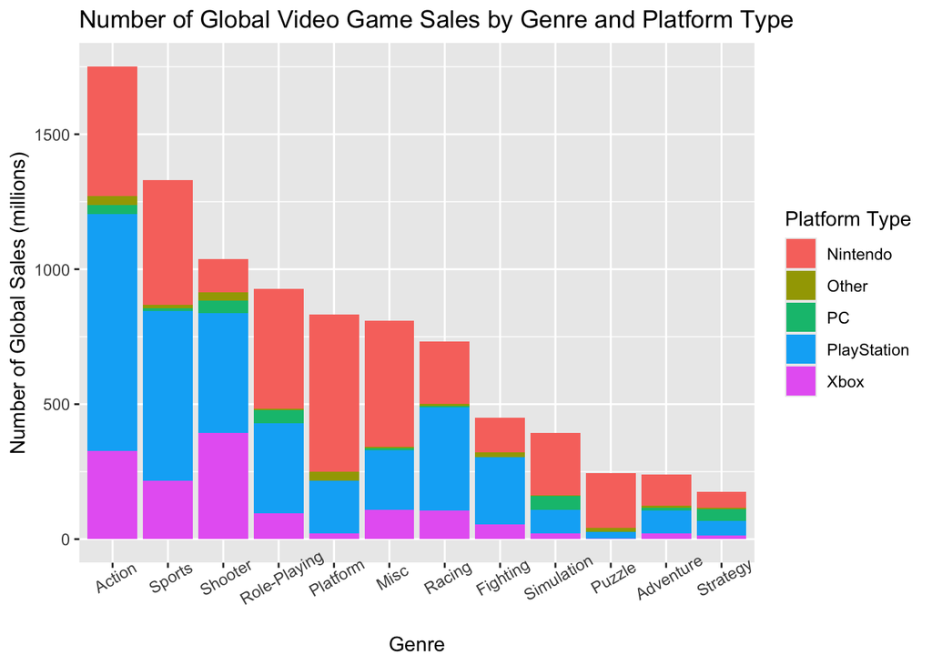

We can see from the graph that Action is the most popular genre, followed by Sports and Shooter, whereas the least popular genre is Strategy, followed by Adventure and Puzzle. We can also indirectly see that in general, Nintendo and PlayStation are the more dominant platforms compared to other platforms like Xbox, PC, or Other. It is once agin worth noting that this dataset does not contain digital sales, which could explain the low number of sales for PC, which usually contains games sold digitally.

##### (Research Question 3)

Pivoting to our third research question, examining which factors impact global sales, we will select a variable or two in each graph, and visualize their relationship with sales.

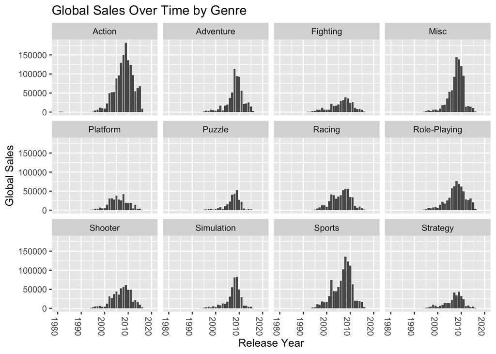

We can also examine how different platform types have performed over time by looking at individual game sales with platform-specific trend lines:

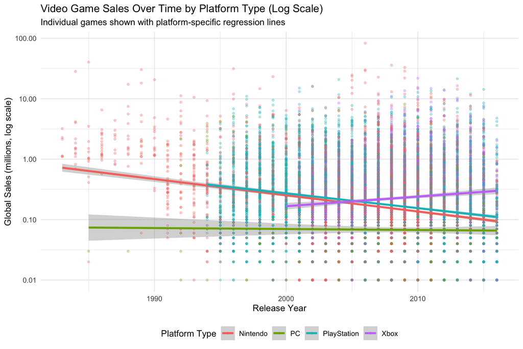

This scatterplot displays individual game sales, with a log transform on that variable for graph readability, over time, with each point representing a single game colored by its platform type. The regression lines are also colored by platform type, revealing that Nintendo and PlayStation see a consistent drop in global sales per game, with the linear decrease suggesting an exponential decrease outside of the log transform. The inverse is true for Xbox, with an exponential increase. Finally, PC remains extremely consistent. Note how this examines sales per game, as the games are plotted individually, and not a total sales sum, which was used in many other of the plots. The shaded confidence intervals around each line indicate the uncertainty in these trends.

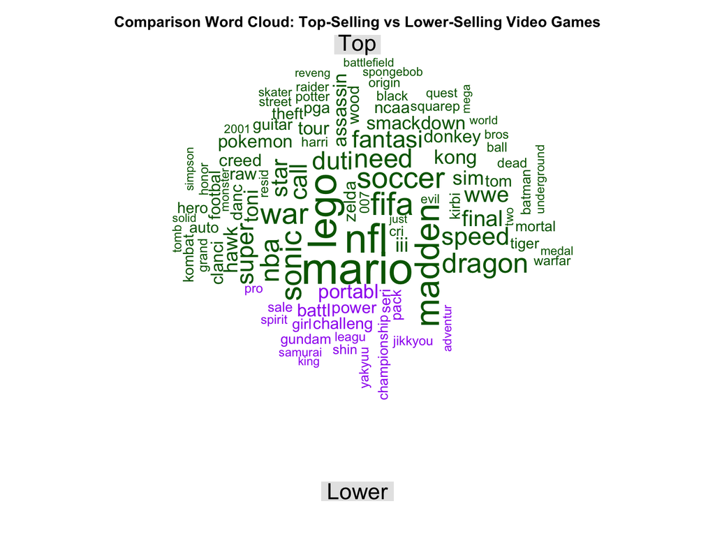

This cloud investigates if something as simple as the title can be used to predict sales. This comparison word cloud highlights the most common words appearing in the titles of top-selling games (top 25% by global sales) versus lower-selling games (bottom 75%). The word cloud reveals that top-selling titles are more likely to include recognizable franchise names and established series. Words like “mario,” “nfl,” “lego,” and other major franchise identifiers appear more prominently in the top-selling category, while lower-selling games contain more generic descriptions, such as “battle” and “portable”. This suggests that brand recognition and established franchises are strongly associated with higher global sales, which makes sense given that well-known series benefit from existing fan bases and marketing recognition.

## Conclusion

Genre preferences also differed significantly across regions. Our chi-square test also found that North America, Europe, and Japan have distinct sales distributions by genre, with Japan’s strong emphasis on role-playing games standing in contrast to the action-, shooter-, and sports-heavy markets of North America and Europe. These differences highlight how cultural preferences could shape the demand for different types of games.

Finally, when considering factors that may influence global sales, we found patterns across release year, platform type, and even game titles. Platform analysis revealed different trajectories, with Nintendo and PlayStation titles showing decreasing sales per game and Xbox titles trending upward. Once again, we might consider the emergence of selling games digitally as a possible factor here. Also, the word cloud comparison suggested that franchise recognition is important in commercial top-selling games, indicating the importance of branding and popularity for consumers in the industry

Overall, our findings show that video game sales are shaped by a combination of time-based trends, regional preferences, differences in genre and platform, and how well known a franchise is . While limited to physical game sales, the dataset provides valuable insight into the structure and evolution of the industry.

## Future Work

Our project answers some basic questions about how video game sales differ over time, across regions, and by genre, but it also raises several questions we could not address with the current data and methods.

First, we do not observe anything about game quality or marketing, such as review scores, user ratings, advertising budget, or development costs. Because of this, we cannot answer questions like “Do highly rated games sell more than average games after controlling for genre and platform?” or “Is marketing more important than genre or region for creating a blockbuster?” Answering these questions would require merging this dataset with external sources (for example, review sites or publisher reports).

Second, the dataset only includes older physical releases that sold at least 100,000 copies, and it aggregates the world into four broad regions. This prevents us from studying modern topics such as indie games, digital-only titles, free-to-play mobile games, or microtransaction revenue, and it also means we cannot look at differences between specific countries within Europe or North America. Future work could use more recent, country-level datasets to ask whether the genre and region patterns we see still hold in today’s market.

Finally, our analysis uses relatively simple tools: summary plots, and chi-square tests. More advanced techniques, such as time-series forecasting for console lifecycles, logistic regression or tree-based models to predict whether a game becomes a “hit,” or clustering to group similar sales profiles, would allow us to model the industry in more detail. These methods go beyond what we have formally covered in this course, so we treat them as natural extensions rather than part of our main analysis.